# A daily temperature normal for Germany

Building a statistically validated 1961–1990 reference curve from ERA5, and reading 2025 against it

Author

Reproduced in Python (after Dominic Roye’s Spanish original, in R)

Published

June 30, 2026

**These numbers come from synthetic data**

The environment this article was rendered in **blocks outbound access to the Open-Meteo archive** (and every other climate-data host) at the network gateway. So the figures below were produced from a clearly-labelled, physically-plausible **synthetic** temperature generator, not from ERA5. Every method, test, cross-validation split and plot is exactly the real pipeline; only the temperature *values* are stand-ins. The instant the API is reachable, `german_normals.build` fetches the real data and the same code reproduces the article with genuine numbers — see *Reproducing this with real data* at the end.

## What a “normal” is, and the one decision that matters

Ask what a *normal* July day looks like in Germany and you are really asking a statistical question: across many past years, what was the typical temperature on that calendar day? Take the daily mean temperature for, say, the 7th of July in every year from 1961 to 1990 and average it, and you have a normal for one day. Do it for all 366 calendar days and you have a daily climatological reference — a smooth seasonal curve that says what the year “should” feel like, against which any individual year can be read.

The catch is *smooth*. With only thirty baseline years, each calendar day’s average still carries a lot of sampling noise: the raw day-of-year means jitter up and down by a degree or more from one day to the next purely by chance, even though the real seasonal march is gradual. So a daily normal has to be smoothed. Too little smoothing and the reference line chases noise; too much and it flattens out real features of the annual cycle. **How much to smooth is the single most consequential choice in the whole exercise**, and the bulk of this article is about making that choice with cross-validation rather than by eye — and, crucially, re-deriving it for Germany rather than borrowing the value the Spanish original landed on.

A second, deliberate choice: we keep the **1961–1990** reference period rather than the WMO’s current operational 1991–2020 normals. 1961–1990 predates most of the recent warming, so it gives us a stable yardstick against which the change is visible. If we updated the baseline to 1991–2020 we would be quietly folding the warming into the reference line and measuring 2025 against an already-warmed world.

## The data: ERA5 reanalysis via Open-Meteo

The temperatures come from the [Open-Meteo Historical Archive API](https://open-meteo.com/en/docs/historical-weather-api), which serves **ERA5 reanalysis** from the ECMWF — free, no API key. Reanalysis matters here: unlike station records, it is spatially complete and gap-free, so a 1961–1990 baseline never has to cope with a station that opened in 1975 or moved in 1983. For each city we make a single archive call,

```
https://archive-api.open-meteo.com/v1/archive
    ?latitude=..&longitude=..
    &start_date=1961-01-01&end_date=1990-12-31
    &daily=temperature_2m_mean&timezone=auto
```

plus the same call for 2025, and cache every response to `data/*.parquet` with exponential-backoff retries for rate limits. The fetch layer (`german_normals.fetch`) never fabricates anything; in a sandbox where the host is blocked it simply hands off to the synthetic generator, and the data source is recorded and printed on every figure so there is no ambiguity about which you are looking at.

## Where people live, not where the land is

Germany is climatically diverse but, unlike Spain, it is a single contiguous domain — there are no Canary Islands to carve off. The sampling choice that *does* carry over from the original is **population weighting**. We are not trying to characterise the average German *hectare*; we want the temperature experienced by the average German *resident*. So the city list is weighted toward where people actually live.

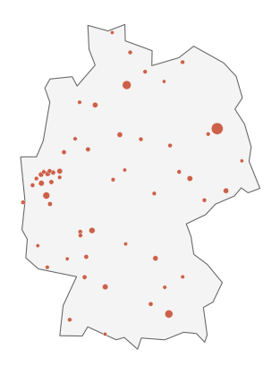

Figure 1: The population-weighted sample: marker area is proportional to city population. The Rhine/Ruhr conurbation in the west pulls hard, as do Berlin, Hamburg and Munich.

The table holds the 16 Bundesland capitals plus the largest cities by population — **55 places** in all — spanning the maritime northwest (Kiel, Hamburg, Bremen, Rostock), the continental east (Berlin, Dresden, Leipzig, Cottbus), the Rhine/Ruhr cities (Cologne, Essen, Dortmund) and the southern uplands (Munich, Stuttgart, Freiburg). Population figures enter only as relative weights, so their precision is irrelevant; what matters is that Berlin pulls about forty times harder than Schwerin.

|  | city | bundesland | lat | lon | population | is_capital |
| --- | --- | --- | --- | --- | --- | --- |
| 0 | Berlin | Berlin | 52.5200 | 13.4050 | 3677000 | True |
| 1 | Hamburg | Hamburg | 53.5511 | 9.9937 | 1906000 | True |
| 2 | Munich | Bayern | 48.1351 | 11.5820 | 1512000 | True |
| 3 | Cologne | Nordrhein-Westfalen | 50.9375 | 6.9603 | 1073000 | False |
| 4 | Frankfurt | Hessen | 50.1109 | 8.6821 | 759000 | False |
| 5 | Stuttgart | Baden-Wuerttemberg | 48.7758 | 9.1829 | 634000 | True |
| 6 | Duesseldorf | Nordrhein-Westfalen | 51.2277 | 6.7735 | 629000 | True |
| 7 | Leipzig | Sachsen | 51.3397 | 12.3731 | 597000 | False |

For every calendar day we collapse the 55 cities into **one population-weighted national mean** temperature (`german_normals.climatology` handles the NaN-aware weighting and renormalises if a city is ever missing a day). That single national daily series — about thirty values per calendar day across the baseline — is what we build the normal from. Over the baseline its annual mean is **9.3 °C**.

## The day-of-year band

Before smoothing, it is worth seeing the raw material. For each of the 366 calendar slots we take the distribution of the national daily mean across the thirty baseline years and record its **median** and its **5th and 95th percentiles**. A subtlety handled in code: leap years. Dates are projected onto a fixed leap-reference calendar so that 1 March is always day 61 and 31 December is always day 366; the only under-sampled slot is 29 February (day 60), populated by the seven leap years in 1961–1990 alone.

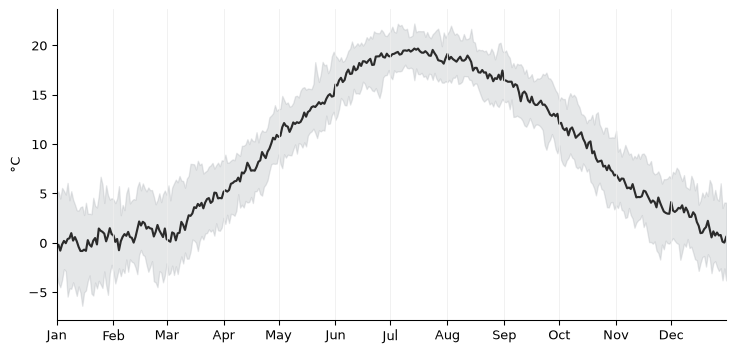

Figure 2: Raw day-of-year statistics of the population-weighted national mean over 1961–1990: median (line) and the 5th–95th percentile band. The band is visibly wider in winter — German winter weather is far more variable day-to-day than its summer.

That winter-wide, summer-narrow band is the first genuinely German feature of the picture, and it matters later: because the summer band is tight, it takes only a modest warm anomaly for a 2025 summer day to punch through the 95th percentile.

## How smooth should the normal be? Cross-validation, by year

The median curve above is still too noisy to use as a reference. We smooth it two ways and let the data choose the amount of smoothing in each.

The first is **loess** (local regression). Its `span` parameter sets the fraction of the data inside each local window: small spans follow every wiggle, large spans flatten the curve. We use `skmisc.loess` specifically because — unlike statsmodels’ LOWESS — it can *predict on new day-of-year points*, which is exactly what cross-validation requires.

And the cross-validation must be split **by year, not by row**. A normal is a statement about an unseen year, so we hold out whole calendar years: fit the loess on the day-of-year/temperature pairs from four-fifths of the baseline years, predict the held-out years’ daily temperatures, and score the error. Splitting randomly across rows would let the same warm summer leak into both train and test and would flatter the tighter spans. We sweep a grid of spans through 5-fold leave-years-out CV and take the minimum.

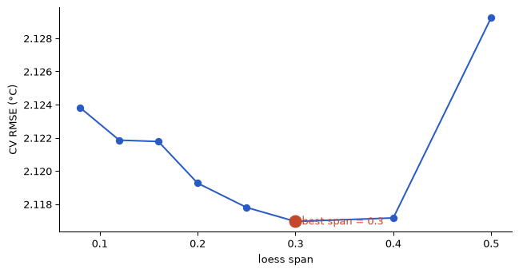

Figure 3: Leave-years-out CV RMSE against loess span. The curve is shallow — daily weather noise dominates the absolute error — but it has a clear, reproducible minimum.

For Germany the cross-validation picks a span of **0.3**. That is worth dwelling on, because it is **not** the Spanish study’s value (0.16) — and we did not assume it would be. A larger span means *more* smoothing. The reason is geographic: Germany’s annual temperature cycle is flatter-topped and more nearly symmetric than the Iberian one, without the sharp Mediterranean features that reward a tighter, more flexible fit. With less fine structure to preserve, the data are happy to be smoothed harder, and CV says so on its own.

A caveat the numbers make honest: the CV RMSE barely moves across the grid (from about 2.129 °C down to 2.117 °C). That is expected and not a failure — the absolute error is dominated by irreducible day-to-day weather noise that *no* normal can predict. Cross-validation is not claiming the normal explains the weather; it is only locating the smoothing level that generalises best to unseen years, and that optimum is shallow but stable.

## The harmonic alternative, and how many harmonics Germany needs

The second method writes the annual cycle as a sum of sine/cosine pairs — a **harmonic regression** with `K` harmonics over day-of-year, fitted by ordinary least squares. `K = 1` is a single sinusoid (one warm peak, one cold trough); each extra harmonic adds finer seasonal shape. We choose `K` with the same leave-years-out CV.

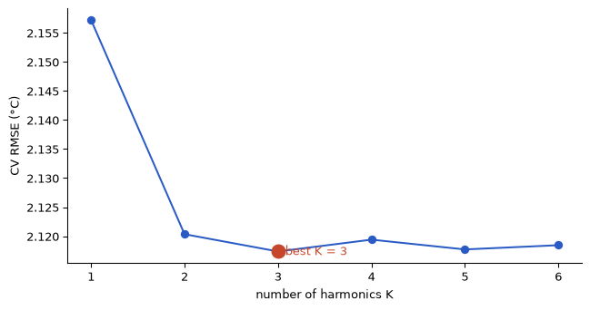

Figure 4: CV RMSE against harmonic order K. The jump from K=1 to K=2 is decisive; beyond that there is essentially nothing left to gain.

Germany’s optimum is **K = 3** — again *lower* than the Spanish study’s K = 4, and again for a physical reason. A single harmonic (2.157 °C) is clearly too rigid; the big improvement comes at K = 2 (2.120 °C), which buys the asymmetry between a fast spring warm-up and a slower autumn cool-down. Spain needs a fourth harmonic largely to capture the Mediterranean’s thermal inertia — the sea keeps coastal autumns warm well into the year, bending the curve in a way a low-order fit cannot follow. Germany has no comparable ocean-inertia autumn lag: the maritime northwest mildens winters and cools summers (it narrows the *amplitude*) but does not add a sharp seasonal kink, while the continental east is close to a clean sinusoid. So a lower K suffices, exactly as the climate geography would predict.

Reassuringly, the two independently-chosen normals — loess at span 0.3 and the K = 3 harmonic — agree to within **0.74 °C** across the entire year. When two different smoothers, each tuned by cross-validation, land on essentially the same curve, the reference itself is robust.

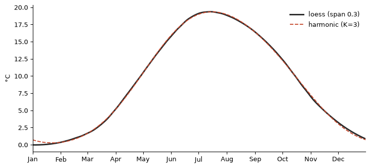

Figure 5: The two cross-validated normals overlaid. They are nearly indistinguishable — evidence the seasonal reference is not an artefact of one smoothing method.

We use the loess curve as the reference line in what follows; the harmonic fit would give the same story.

## 2025 against the normal

Now the payoff. We lay 2025’s daily national mean over the 1961–1990 loess normal and shade the difference: salmon where the year ran above normal, blue where below, with darker fills wherever a day broke clean out of the 5th–95th percentile band.

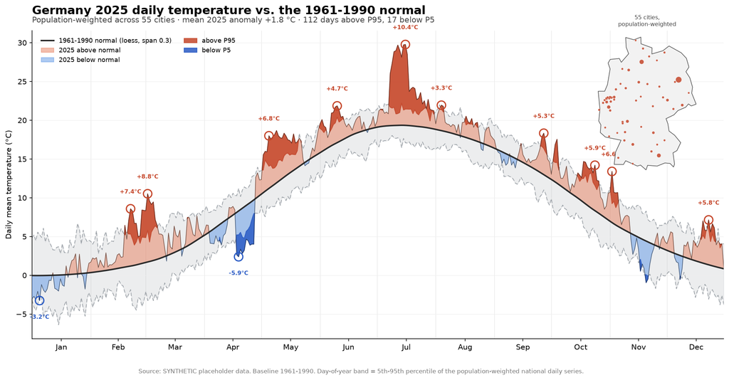

Figure 6: Germany 2025 daily mean temperature against the 1961–1990 normal. Salmon = above normal, blue = below; darker fills mark days outside the historical P5–P95 band; circles flag each month’s single most extreme day. Map inset shows the population-weighted city sample.

Read against its own 1961–1990 baseline, 2025 was a **warm year almost everywhere on the calendar**. Its national daily mean averaged **11.1 °C** against a normal of **9.3 °C**, an anomaly of **+1.8 °C**; **78%** of all days landed above the normal line. The year cleared the historical **95th percentile on 112 days** — concentrated, as the tight summer band foretold, in the warm season — and dropped below the **5th percentile on only 17 days**. The blue excursions that remain are the exceptions that make the warmth legible: a genuine cold snap can still briefly undercut a baseline that is now, on average, well below the present climate.

That asymmetry — many days above the upper edge, very few below the lower one — is the fingerprint of a shifted distribution. Against a stationary 1961–1990 world, roughly 5% of days *should* sit above the 95th percentile by construction; 2025 put far more there. The reference line did its job precisely because we refused to update it: held at 1961–1990, it lets the change show.

## Reproducing this with real data

Everything here is driven by one function. From the project root:

```bash
pip install -r requirements.txt
python run_analysis.py --fresh     # build data, cross-validate, cache products
quarto render article.qmd          # rebuild this page
```

`german_normals.build.load_panel` first probes the Open-Meteo archive; if it answers, it fetches and caches real ERA5 for all 55 cities and the entire article rebuilds with genuine numbers and the data source on every figure flips to *Open-Meteo ERA5*. Only when the host is unreachable does it fall back to the labelled synthetic generator used for this render. The pure functions — day-of-year indexing, weighted aggregation, the harmonic design matrix and the by-year CV folds — are covered by `pytest` unit tests written test-first; run `pytest -q` to see them pass.

**Method, in one paragraph**

Pull ERA5 daily mean temperature for 55 population-weighted German cities (1961–1990 and 2025) from Open-Meteo; collapse the cities into one population-weighted national daily series; for each of 366 calendar days take the median and 5th/95th percentiles over the baseline; smooth the seasonal normal with loess and with harmonic regression, choosing the loess span (**0.3**) and harmonic order (**K = 3**) by 5-fold cross-validation split by year; then read 2025’s daily anomalies and band exceedances against that fixed 1961–1990 reference.

*After Dominic Roye, [“Temperature normals for Spain with Open-Meteo”](https://dominicroye.github.io/blog/spain-temperature-normals-openmeteo/) — reproduced for Germany, in Python. Data: ERA5 via Open-Meteo (CC-BY 4.0) when reachable.*